# RDD Replication 1

Megan Ellertson

2/14/2021

## Question 1

The link below is connected to my github repository, which I have labeled **EllertsonRDD** due to the fact that I have another repository called RDD in my github, which I made while I was learning to use Git/github I wanted to keep it separate. As an additional note, I began this assignment in both R and STATA. I wanted to use this as an opportunity to learn R (which I am very new to) and expand my skills in STATA. Therefore, this Markdown is completed with the R software as much as possible and to the best of my ability and supplemented with STATA when necessary. My full assignment in STATA with codes are in the RDDReplicationFinal.do in my **EllertsonRDD** repository, as well as the outputted figures and graphs from STATA. When I needed to use STATA I display the code used to produce the output. All R code not outputted for the html document. All of my R code behind the html document can be found in the repository. The .Rmd file is RDDReplication1Ellertson.Rmd. in the Writing folder of the repository.

https://github.com/meganellertson/EllertsonRDD.git

## Question 2

Summary *Punishment and Deterrence: Evidence from Drunk Driving* (Hansen, 2015) attempts to understand the effect of harsher punishments and sanctions on recidivism, particularly related to drunk driving and DUIs. Hansen attempts to further the literature on contradictory conclusions provided by prior criminologists and economists on this topic. In this analysis Hansen analyzes the policy of the DUI, through the blood alcohol content thresholds and a quasi-experimental design to understand the effect that harsher punishment has on people’s inclination to repeat a crime, specifically drinking and driving. Hansen utilizes DUI BAC test data from the state of Washington between 1999 and 2007, this specific time frame allows for the examination of a four year recidivism window as well as the constant nature of the BAC thresholds at 0.08 and 0.15 (aggravated DUI) after 1999. The analysis ensures to look at individuals over the age of 21 given the behavior and punishment for drunk driving is very different. Hansen utilizes a McCrary Density test prior to local linear regression discontinuity design to ensure that the estimates are unbiased. Given the McCrary Density test, Hansen finds that there is no evidence of “endogenous sorting” or, more plainly, that at the cutoff individuals are randomly getting slightly above or slightly below the DUI threshold. This means they cannot sort themselves or be sorted into or out of the DUI charge, it is just locally random. Hansen does confirm this through the density test, and thus can proceed with the regression discontinuity. He utilizes a local linear regression discontinuity to obtain the estimates with slopes that change at the discontinuity and with rectangular kernels. The indicator variable, or dummy variable is when the BAC level is at or above 0.08 or in the case of the aggravated DUI: at or above 015. There are additional controls included such as age, gender, accident at the scene, and race. The running variable is the minimum between the two BAC tests provided at the scene which are usually very close in value. Hansen finds that these punishments do reduce recidivism. He finds that having a BAC at the DUI level or above decreases recidivism by 2 percentage points during the four years after the initial conviction (this is statistically significant at the 1%). Similar results are found for the aggravated DUI level. The study also looks at how increasing severity of punishment impacts diversion. He finds that a 10% increase in sanctions for drunk driving reduces the act by 2.3%. Hansen also addresses some other factors which contribute to recidivism rates such as incapacitating,rehabilitation and deterrence. Deterrence ends up being the primary way for addressing this.Although Hansen also notes that the identification strategy is limited due to the inability to assess the effect of more severe punishments and testing for those who are first time offenders.

## Question 3

```r
RDDdata <- raw_hansen_dwi %>%
  mutate(dui = car::Recode(bac1, "lo: 0.08=0; else = 1"))
```

```stata
gen dui = 0
replace dui = 1 if bac1>=0.8
sum dui
```

*Was unable to change STATA directory within R*

Summary Statistics Table

| Variables | Mean | Standard Deviation | Minimum | Maximum |
| --- | --- | --- | --- | --- |
| Recidivism | 0.12 | 0.32 | 0 | 1.00 |
| BAC | 0.14 | 0.05 | 0 | 0.45 |
| DUI | 0.89 | 0.31 | 0 | 1.00 |
| Male | 0.79 | 0.41 | 0 | 1.00 |
| Accident | 0.15 | 0.35 | 0 | 1.00 |
| Age | 34.96 | 11.50 | 21 | 80.00 |
| White | 0.86 | 0.35 | 0 | 1.00 |

Note: The summary statistics above are provided for the relevant variables for this replication.

## Question 4

The following recreates the frequency distribution which is the method Hansen chooses to visualize the potential sorting behavior along the running variable which may be a form of manipulation. This is important to understand because, if individuals were able to control or sort themselves into the treatment group, it would take away from the ability to utilize the RDD method to draw any casual effects. The sorting would be cause for basis and would change the meaning of the results.

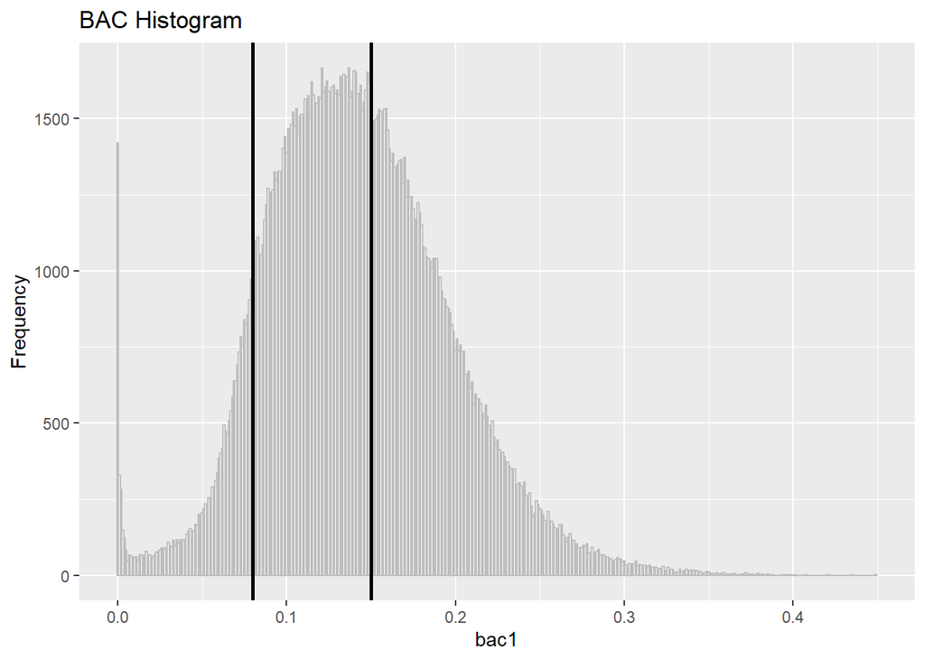

Visually, the frequency distribution appears very smooth, and there appears to be no bunching behavior around the cutoff which is indicated by the vertical line. The 0.15 line is included as well to remain as consistent with Hansen’s figure as possible. Although visually, this appears may provide for some confidence to the lack of endogenous sorting, it may be more effective to use an additional density test, the McCrary Density test to ensure this conclusion.

```
Manipulation testing using local polynomial density estimation.

Number of obs =       214558
Model =               unrestricted
Kernel =              uniform
BW method =           estimated
VCE method =          jackknife

c = 0.08              Left of c           Right of c
Number of obs         23010               191548
Eff. Number of obs    14442               28946
Order est. (p)        2                   2
Order bias (q)        3                   3
BW est. (h)           0.023               0.023

Method                T                   P > |T|
Robust                -0.0508             0.9595


P-values of binomial tests (H0: p=0.5).

Window Length / 2          <c     >=c    P>|T|
0.000                     909       0    0.0000
0.000                     909       0    0.0000
0.000                     909       0    0.0000
0.000                     909       0    0.0000
0.000                     909       0    0.0000
0.000                     909       0    0.0000
0.000                     909       0    0.0000
0.000                     909       0    0.0000
0.000                     909       0    0.0000
0.000                     909       0    0.0000
```

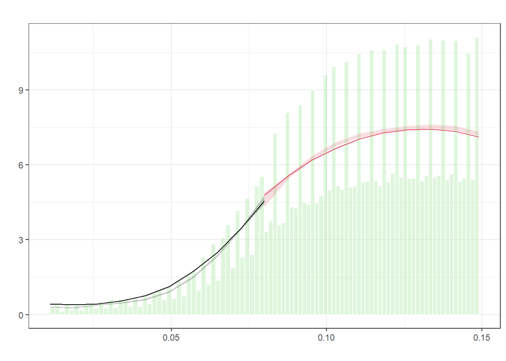

[output not shown]

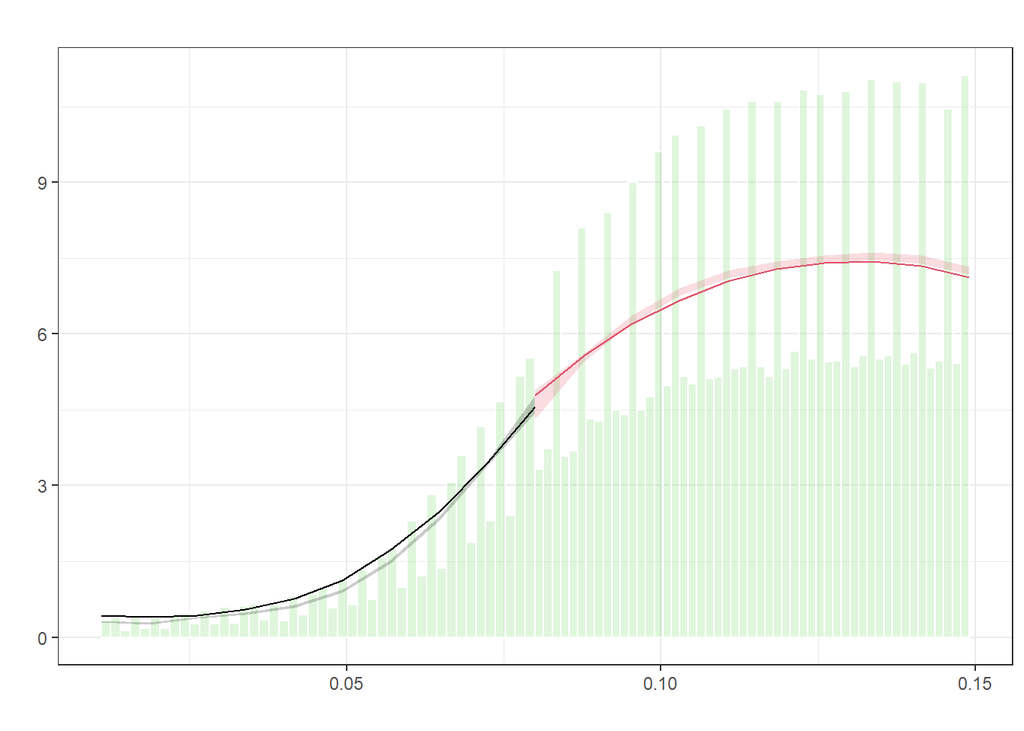

The output of this test provide a p-value of 0.9595. Given the high p-value there is substantial evidence that there is no endogenous sorting impacting the data. This allows the RDD method to move forward with the ability to draw casual effect conclusions. Additionally, a density plot is produced which visualizes the cutoff of 0.08, the black line is prior to the cutoff and the red line is after the cutoff or the portion of the sample which would have received DUIs. It would make sense that there would not be sorting in the running variable for a few reasons, many of which are pointed out in Hansen’s paper. Given the running variable is BAC, it is an extremely difficult measurement for an individual to control and particularly to control right at the DUI level. The BAC is very specific to the individuals body, and their activities, not to mention the difficulty in judgment one would suffer if they were even to attempt to control their BAC while drinking. Additionally, how the BAC is measured is extremely precise, therefore, it would be difficult to control for at such a specific level.

## Question 5

The following is the first equation specified by Hansen for the estimation method. In this equation the variable recidivism is the dependent variable for every “i” individual, the large “X” is the vector of the covariates which are being controlled for, such as sex, age and race. Then there are independent variables estimations for the indicator variable for DUI, the BAC level and then the interaction between the two.

**Equation 1** $y_i = X_i'\gamma +\alpha_1DUI_i + \alpha_2BAC_i +\alpha_3BAC_i *DUI_i +u_i$

The next step is to check the covariate balance, which recreates the first panel of Table 2 in Hansen’s paper.

Table 2: Covariate Balance Panel A Only

| Characteristic | Male | White | Age | Accident |
| --- | --- | --- | --- | --- |
| Coeff | 0.007 | 0.006 | -0.148 | -0.003 |
| SE | 0.006 | 0.005 | 0.164 | 0.004 |
| Z | 1.142 | 1.241 | -0.906 | -0.786 |
| P-Value | 0.254 | 0.215 | 0.365 | 0.432 |
| Confidence Interval | -0.005 | -0.004 | -0.470 | -0.011 |

Note: The table above provides the covariate balance estimation. This includes using the RDestimate command to regress the characteristic onto the BAC level controlling for the original estiamtion equation. This utilizes rectagular kernels and bandwiths of 0.05. The P-values outputed display the signficance levels for the estimate

## Question 6

Figure 2 from Hansen looks at the covariate balance. This takes into account the covariates which will be used to control for. We must examine how these interact with the running variable individually to draw more consistent and unbiased conclusions from our full RDD estimates. The visualization of this covariate specific understanding looks at the shape of the scatter plots around the cutoff, as well as the shape of the relationship of the covariate along the running variable. The first provided set of graphs is created and combined with STATA, this provides a linear fit for the scatter plot on either side of the cutoff. The following is both the linear and the quadratic fit for these regressions, and uses the cmogram command in STATA.

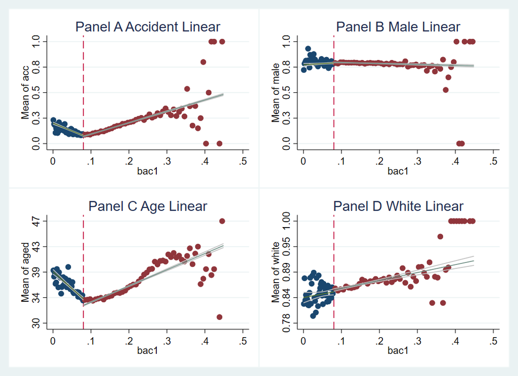

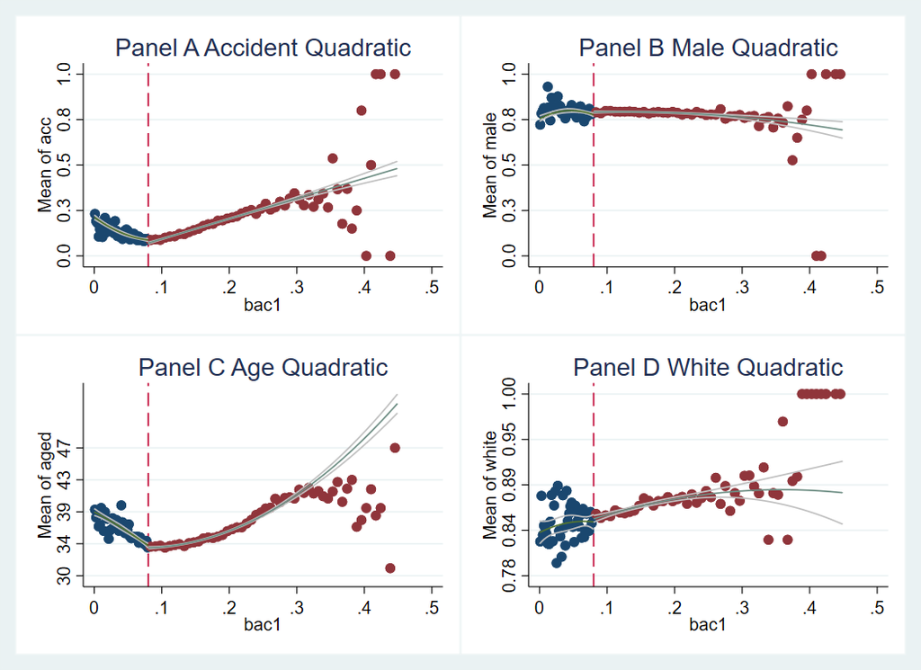

```stata
cmogram acc bac1, cut(0.08) scatter line(0.08) lfitci title("Panel A Accident Linear")
**Figure3.gph
cmogram male bac1, cut(0.08) scatter line (0.08) lfitci title("Panel B Male Linear")
**Figure4.gph
cmogram aged bac1, cut(0.08) scatter line(0.08) lfitci title("Panel C Age Linear")
**Figure5.gph
cmogram white bac1, cut(0.08) scatter line(0.08) lfitci title("Panel D White Linear")
**Figure6.gph


graph combine Figure3 Figure4 Figure5 Figure6, replace
**linear.gph

cmogram acc bac1, cut(0.08) scatter line(0.08) qfitci title("Panel A Accident Quadratic")
**Figure11.gph
cmogram male bac1, cut(0.08) scatter line (0.08) qfitci title("Panel B Male Quadratic")
**Figure12.gph
cmogram aged bac1, cut(0.08) scatter line(0.08) qfitci title("Panel C Age Quadratic")
**Figure13.gph
cmogram white bac1, cut(0.08) scatter line(0.08) qfitci title("Panel D White Quadratic")
**Figure14.gph

graph combine Figure11 Figure12 Figure13 Figure14
**quadratic.gph
```

The image can also be created with the rdplot command in STATA.

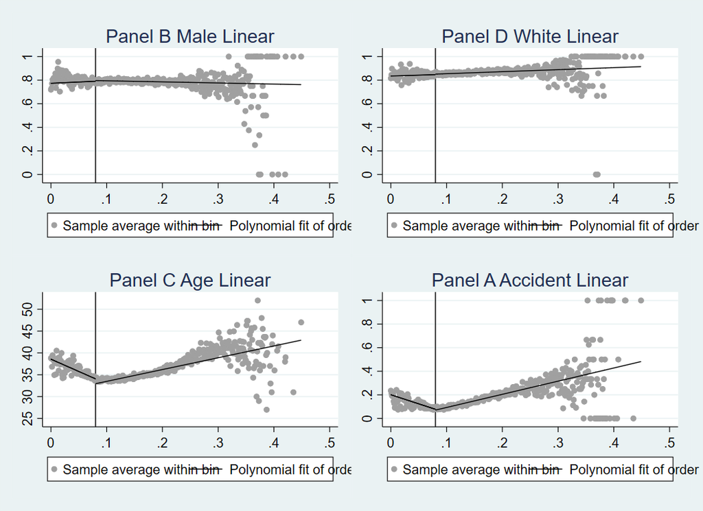

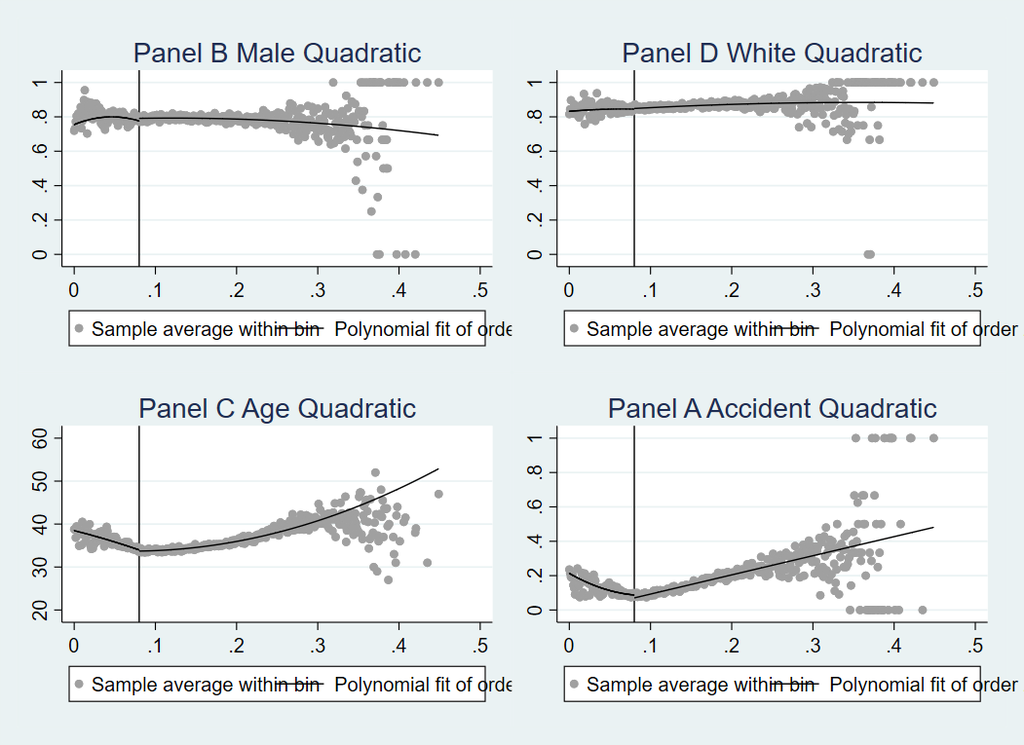

```stata
rdplot male bac1, c(0.08) p(1) bw(0.05) graph_options(title("Panel B Male Linear"))
**Figure7.gph
rdplot white bac1, c(0.08) p(1) graph_options(title("Panel D White Linear"))
**Figure8.gph
rdplot aged bac1, c(0.08) p(1) graph_options(title("Panel C Age Linear"))
**Figure9.gph
rdplot acc bac1, c(0.08) p(1) graph_options(title("Panel A Accident Linear"))
**Figure10.gph

graph combine Figure7 Figure8 Figure9 Figure10, replace
**linear2.gph

rdplot male bac1, c(0.08) p(2) graph_options(title("Panel B Male Quadratic"))
**Figure15.gph
rdplot white bac1, c(0.08) p(2) graph_options(title("Panel D White Quadratic"))
**Figure16.gph
rdplot aged bac1, c(0.08) p(2) graph_options(title("Panel C Age Quadratic"))
**Figure17.gph
rdplot acc bac1, c(0.08) p(2)  graph_options(title("Panel A Accident Quadratic"))
**Figure18.gph

graph combine Figure15 Figure16 Figure17 Figure18
**quadratic2.gph
```

## Question 7

To proceed with the RDD estimation, Table 3 from Hansen’s paper, is replicated with a few specific manipulations. In this, we will be focusing on the DUI estimate or the effect at the cutoff which is what is of interest. There are a few stipulations which are provided in the footnote of the table below. The bandwidth around the cutoff (DUI) is evaluated at 0.05 and 0.025 above and below the cutoff, this is separated by Panel A and Panel B respectively. Additionally, this table examines the estimated effect of DUI with just the running variable is controlled for (Condition 1), when there is a linear interaction between the cutoff and the running variable (Condition 2) and when there is a quadratic interaction between the running variable and the cutoff (Condition 3). Note that all of these estimates use the robust standard errors through the use of the lm_robust command.

Table 3: Regression Discontinuity Estimates for the Effect of Exceeding the 0.08 bac Threshold on Recidivism

| Panels | Condition 1: BAC Alone | Condition 2: Linear Interaction | Condition 3: Quadratic Interaction |
| --- | --- | --- | --- |
| Panel A Bandwith 0.05 | -0.027 | -0.024 | -0.014 |
| StErrs | 0.004 | 0.004 | 0.006 |
| pvalue | 0.000 | 0.000 | 0.021 |
| Panel B Bandwith 0.025 | -0.022 | -0.020 | -0.015 |
| StErrs | 0.006 | 0.006 | 0.008 |
| pvalue | 0.000 | 0.000 | 0.075 |

Note: The table above replicates the Table 3 from Hansen (2015). Panel A represents the estimates with a bandwith of 0.05 and Panel B represents estiamtes with a bandwidth of 0.025, the data used here is centered, therefore the bandwiths represented frame -0.05 to 0.05 and -0.025 to 0.025 respectively. Condition 1 controls for BAC linearly, Condition 2 controls for the linear interaction between BAC and the DUI cutoff, and Condition 3 controls for the quadratic interaction between BAC and the DUI cutoff. The estimates of interest is the DUI variable therefore, it is the only variable from the model represented in the table. P-values are provided below to show statistical signficance. The esitmations use rectangular kernel weights.

The estimates produced are as displayed in the table above. There are some interesting items to note about this output. All are statistically significant at a 95% level, except for the Quadratic Interaction in Panel B. All estimates of the effect of having BAC over the DUI threshold are negative. All of these estimates also control for gender, race, age and the accident level. These estimates can be interpreted as follows: the effect of having a BAC level above the DUI cutoff of 0.08 decreases recidivism by about 2 percentage points at both bandwidth levels and when a linear interaction is included in the estimation. However, the estimate decreases slightly and the p-values increase slightly when the quadratic interaction is included. This can be conceptualized to mean that those with a BAC at or above the DUI threshold are less likely to have another pull over for drunk driving in the next few years, so the likeliness of recidivism goes down. This would speak to the effectiveness of the policy at reducing instances of drunk driving.

## Question 8

The following visualization was created with STATA with two different commands for two different visualization types. The first uses the cmogram and the second rdplot. Note the cmogram command did not allow for cutting off the data at the 0.15 high level but the rdplot did allow for this. These are both plotted linearly and quadratically These plot recidivism as the dependent with respect to the running variable of BAC level and can be analyzed at the 0.08 cutoff. The figures below display a distinguishable drop in recidivism at the 0.08 BAC level. This is a similar conclusion to Hansen’s paper. This aligns with the conclusions and interpretation of the Table 3 estimates in Question 7. The policy is showing an reduction on recidivism of drunk driving.

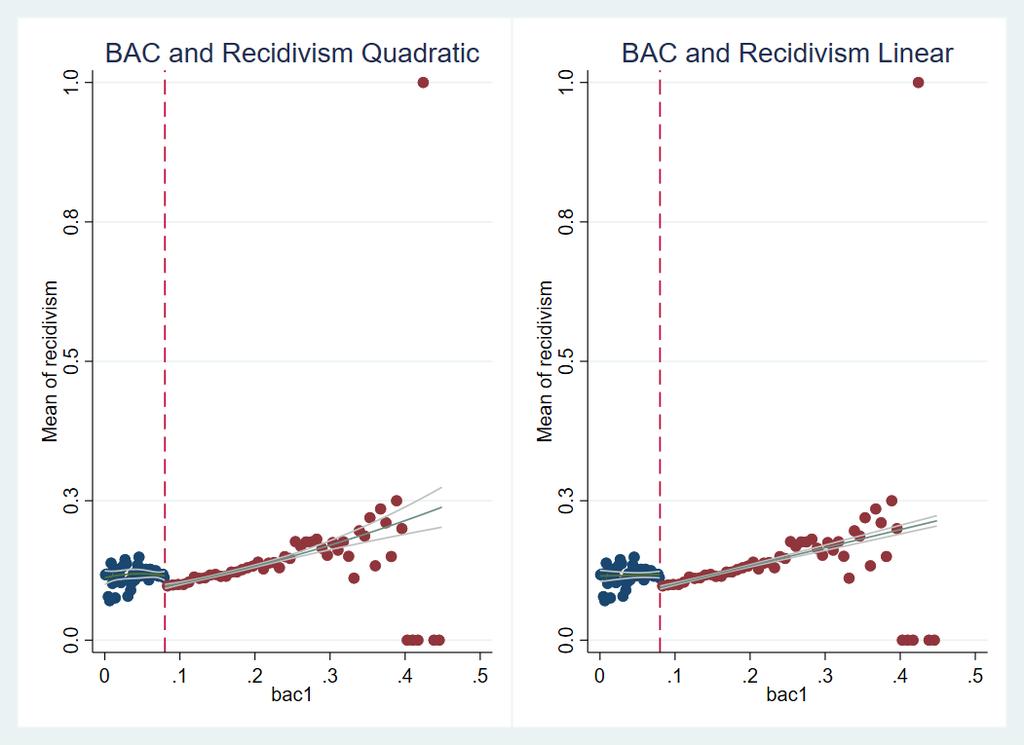

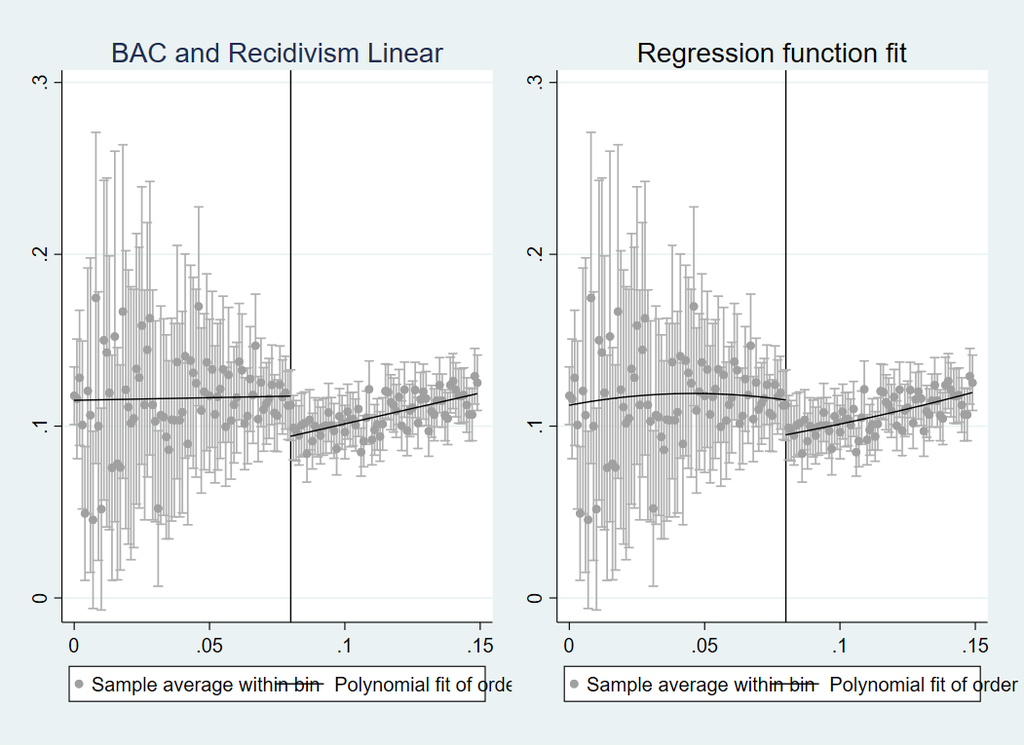

```stata
cmogram recidivism bac1, cut(0.08) scatter line(0.08) qfitci title("BAC and Recidivism Quadratic")
**Figure19.gph
cmogram recidivism bac1, cut(0.08) scatter line(0.08) lfitci title("BAC and Recidivism Linear")
**Figure20.gph

graph combine Figure19 Figure20
**Basic.gph

rdplot recidivism bac1 if bac1 < 0.15, c(0.08) p(1) ci(95) graph_options(title("BAC and Recidivism Linear"))
**Figure21.gph
rdplot recidivism bac1 if bac1 < 0.15, c(0.08) p(2) ci(95) graph_option(title("BAC and Recidivism Quadratic"))
**Figure22.gph

graph combine Figure21 Figure22
**Basic2.gph
```

## What I learned

This replication helped me to not only understand the mechanics of Regression Discontinuity Design, but also I have gained a significant amount of technical skills. Prior to this assignment I was very unfamiliar with R, git, github, and markdown formats. Given I also completed this work in STATA, I also worked with commands I was unfamiliar with in that software. Going through the processes of replication and working through the underlying code, especially in R, gave me a more concrete understanding of the processes happening in the estimation method. The most integral aspect was the visualizations which assisted in my understanding of how RDD works and when it is appropriate. RDD seems to be an effective method when understanding the effects of specific policies and types of cutoffs. Specifically analyzing the localized effect appears to be important in many different context.